# Data

Published

29-Sep-2023

**Note**

Datasets are presumably of three types:

1. simulated data
2. experimental data
3. precomputed results

Datasets 1 and 2 will be used for analyses. Datasets of type 3 are results that take a long time to compute (e.g. on a HPC) and will be needed to enable compilation of jupyter book examples

**Note**

This document describes data sets used to generate slides, exercise results and examples in general.

All data reside in a dedicated data repository at https://github.com/NBISweden/pgip-data. Datasets consist of genome sequences, bam files, variant call files, and tree sequences, among other things. Data generation is discussed briefly below. See the [pgip-data README](https://github.com/NBISweden/pgip-data/README.md) for more information.

## Datasets used on website

Simulated datasets reside in the `data` subdirectory (Table 1).

Table 1: Simulated dataset

| Dataset | Description | Location |
| --- | --- | --- |
| ooa | Out of Africa | `data/ooa` |
| ooa-outgroups | Out of Africa with outgroups | `data/ooa-outgroups` |
| sweep | Selective sweep data | `results/slim` |

## Simulated SLiM recipes

[SLiM](https://messerlab.org/slim/) recipes reside in `docs/recipes/slim`. The output can be generated with the helper script `pgip-slim` from the software repo pgip-tools.

## Simulated demographic models

**FIXME**

Desired improvements:

- base mutations are random; model realistic ti/tv ratios better

Demographic models are defined using the [Demes specification](https://popsim-consortium.github.io/demes-spec-docs/main/introduction.html). For neutral models, genealogies and mutations are [simulated with msprime](https://tskit.dev/msprime/docs/stable/ancestry.html) and saved as [succinct tree sequences](https://tskit.dev/learn.html#what) that can be converted to standard variant call format (vcf) files.

The variant data represents the true state of the model. In addition, we can assign haplotypes to each individual from which sequence reads can be simulated. One simulated individual is chosen as reference and a reference sequence is generated, either from experimental data or randomly, for that individual. Given the reference and the variant data, haplotype sequences are generated for each individual in the model. The haplotype sequences are then used as templates to generate sequencing reads with realistic error profiles. Currently [InSilicoSeq](https://insilicoseq.readthedocs.io/en/latest/index.html) is used to simulate reads.

Simulated reads are mapped with bwa to the reference and saved to bam files. The raw data reads and haplotype sequences are finally discarded to save space. Variant calling is done with GATK.

### Out of Africa (ooa)

The out of Africa dataset is based on the Gutenkunst et al. (2009) demographic model (Figure 1; see also [Population tree example](https://tskit.dev/msprime/docs/stable/demography.html#population-tree) and [the stdpopsim out of Africa model specification](https://popsim-consortium.github.io/stdpopsim-docs/stable/catalog.html#sec_catalog_homsap_models_outofafrica_3g09)).

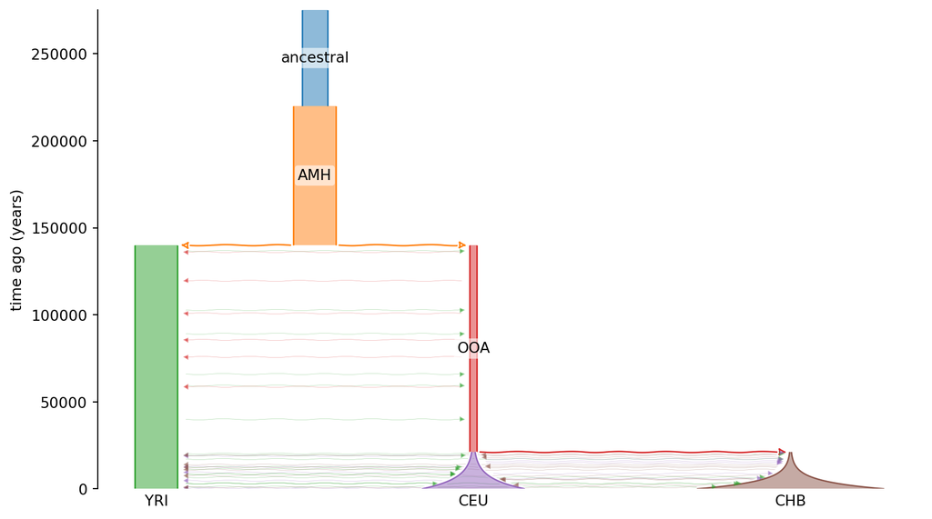

Figure 1: [demesdraw](https://grahamgower.github.io/demesdraw/latest/quickstart.html) illustration of out of Africa model.

Note that this dataset is based on a subset of the data generated in Section 3.2.

### Out of Africa with outgroups (ooa-outgroups)

The out of Africa with outgroups demographic model is an extension of the previous data set (Figure 2). In addition to simulating human data, the model has been expanded to include three outgroups chimpanzee, gorilla and orangutan.

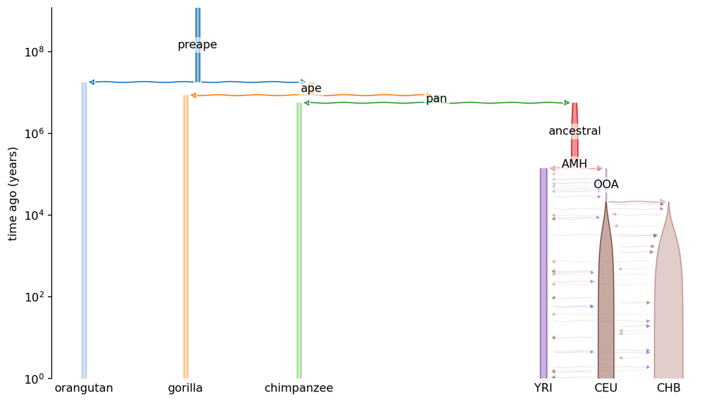

Figure 2: [demesdraw](https://grahamgower.github.io/demesdraw/latest/quickstart.html) illustration of out of Africa model, including outgroups chimpanzee, gorilla, and orangutan. Note that the time scale is in log units.

The data generation has been implemented in a [Snakemake](https://snakemake.readthedocs.io/en/stable/) workflow. See the rulegraph Figure 3 for an overview of the steps to generate data.

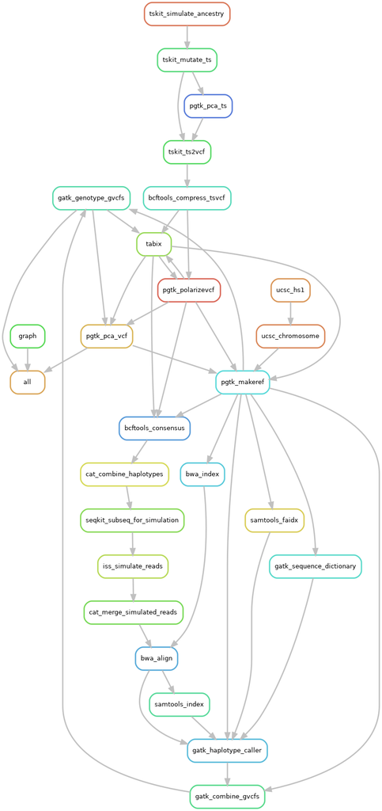

Figure 3: Snakemake rulegraph

## References

Gutenkunst, R. N., Hernandez, R. D., Williamson, S. H., & Bustamante, C. D. (2009). Inferring the joint demographic history of multiple populations from multidimensional SNP frequency data. *PLoS Genetics*, *5*(10), e1000695. https://doi.org/10.1371/journal.pgen.1000695